# Lyric Analysis of Split Enz Songs - Part 1

Phil Nelson

# Split Enz History

Split Enz was one of the most iconic and popular New Zealand Bands in the 1970’s and 1980’s. I’m a fan of Split Enz which is the inspiration for this post and data analysis in R.

Split Enz had eight songs listed in the APRA Top 100 New Zealand Songs of All Time in 2001 more than any other band. They were the first New Zealand act to break into the highly lucrative British and United States markets (https://nzhistory.govt.nz/media/photo/split-enz).

This is the first post based on my Split Enz lyrics analysis of their 9 studio albums https://en.wikipedia.org/wiki/Split_Enz_discography comprising 91 songs during the period 1975 - 1984.

### Plan for Split Enz posts in three parts:

- Part 1 - Split Enz Introduction, Text Mining and Exploratory Analysis (this post)
- Part 2 - Sentiment Analysis and Topic Modelling with Natural-language processing (NLP)
- Part 3 - Analytics using Machine Learning

According to Bradley Collins, BMI Creative, Nashville:

*“The most performed songs at BMI have very simple melodies and lyrics. The relationship between the two musical elements are integrated. Lyrics need melody to convey emotion. Melody needs lyrics to tell the story. A simple melody with strong lyrics is a key component to popular songwriting.”*

https://www.bmi.com/news/entry/whats-the-relationship-between-music-and-lyrics This series of posts only analyses lyrics and does not analyse the musical dimensions of Split Enz songs. It would be really interesting to analyse the music as well but that isn’t in the scope of this analysis…..

Lets load the R packages used in the analysis:

```r
#load packages
library(dplyr) #data manipulation
library(ggplot2) #visualizations
library(gridExtra) #viewing multiple plots together
library(tidytext) #text mining
library(RColorBrewer)
library(tm)
library(wordcloud)
library(readxl)
```

Let’s import and examine the data:

```r
Split_Enz_2 <- read_excel('Split_Enz_2.xlsx')
glimpse(Split_Enz_2)
```

```
## Observations: 91
## Variables: 8
## $ year            <dbl> 1975, 1975, 1975, 1975, 1975, 1975, 1975, 1975...
## $ album           <chr> "Mental Notes", "Mental Notes", "Mental Notes"...
## $ songs           <chr> "Walking Down A Road", "Under The Wheel", "Amy...
## $ lyrics          <chr> "Walking down a road hedged with roses , Time ...
## $ NZ_album_chart  <dbl> 7, 7, 7, 7, 7, 7, 7, 7, 7, 7, 18, 18, 18, 18, ...
## $ AUS_album_chart <dbl> 35, 35, 35, 35, 35, 35, 35, 35, 35, 35, 25, 25...
## $ Aus_Chart       <dbl> NA, NA, NA, NA, NA, NA, NA, NA, NA, NA, 93, NA...
## $ NZ_chart        <dbl> NA, NA, NA, NA, NA, NA, NA, NA, NA, NA, NA, NA...
```

```r
summary(Split_Enz_2)
```

```
##       year         album              songs              lyrics
##  Min.   :1975   Length:91          Length:91          Length:91
##  1st Qu.:1977   Class :character   Class :character   Class :character
##  Median :1980   Mode  :character   Mode  :character   Mode  :character
##  Mean   :1980
##  3rd Qu.:1982
##  Max.   :1984
##
##  NZ_album_chart   AUS_album_chart   Aus_Chart        NZ_chart
##  Min.   : 1.000   Min.   : 1.00   Min.   : 1.00   Min.   : 1.00
##  1st Qu.: 1.000   1st Qu.: 1.00   1st Qu.: 5.25   1st Qu.: 5.50
##  Median : 3.000   Median :18.00   Median :15.00   Median :13.00
##  Mean   : 5.934   Mean   :16.66   Mean   :26.64   Mean   :14.45
##  3rd Qu.: 7.000   3rd Qu.:25.00   3rd Qu.:44.25   3rd Qu.:24.00
##  Max.   :18.000   Max.   :35.00   Max.   :93.00   Max.   :33.00
##                                   NA's   :77      NA's   :80
```

### Song Ratings:

Here is a summary of the NZ song ratings for Split Enz by year:

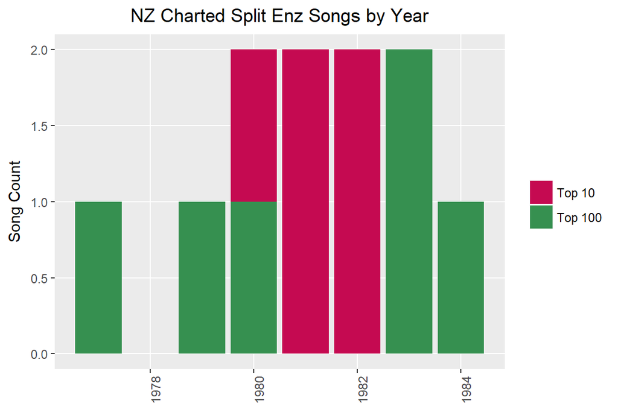

```r
Split_Enz_2 <- Split_Enz_2 %>%
  mutate(charted =
           ifelse(Split_Enz_2$NZ_chart %in% 1:100, "Charted", "Uncharted"))

Split_Enz_2 <- Split_Enz_2 %>%
  mutate(period =
            ifelse(Split_Enz_2$year %in% 1975:1978, "1975-78",
            ifelse(Split_Enz_2$year %in% 1979:1981, "1979-81",
            ifelse(Split_Enz_2$year %in% 1982:1984, "1982-84",
                                                "NA"))))

Split_Enz_2 <- Split_Enz_2 %>%
  mutate(NZsong_chart =
           ifelse(Split_Enz_2$NZ_chart %in% 1:10, "Top 10",
           ifelse(Split_Enz_2$NZ_chart %in% 11:100, "Top 100", "Uncharted")))

#define some colors to use throughout based on the palette of the numerous True Colours #album covers
my_colors <- c("#C50A51", "#369050", "#106BBA", "#FC8622", "#ACC006")

theme_lyrics <- function()
{
  theme(plot.title = element_text(hjust = 0.5),
        axis.text.x = element_blank(),
        axis.ticks = element_blank(),
        panel.grid.major = element_blank(),
        panel.grid.minor = element_blank(),
        legend.position = "none")
}

charted_songs_over_time <- Split_Enz_2 %>%
  filter(NZ_chart > 0) %>%
  group_by(period, NZsong_chart,songs,year) %>%
  summarise(number_of_songs = n())

charted_songs_over_time %>%
ggplot() +
  geom_bar(aes(x = year, y = number_of_songs,
               fill = NZsong_chart), stat = "identity") +
  scale_fill_manual(values = my_colors) +
  theme(plot.title = element_text(hjust = 0.5),
        legend.title = element_blank(),
        panel.grid.minor = element_blank(),
        axis.text.x = element_text(size=9, angle=90)) +
  labs(x = NULL, y = "Song Count") +
  ggtitle("NZ Charted Split Enz Songs by Year")
```

The graph below shows all Split Enz songs summarised by year and chart classification

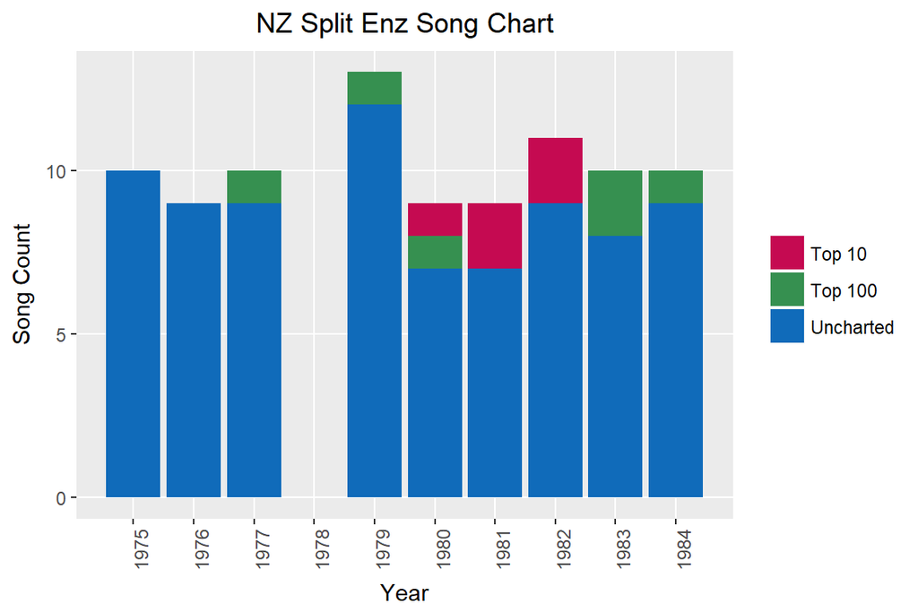

```r
Split_Enz_2 %>%
  group_by(period, NZsong_chart, year) %>%
  summarise(number_of_songs = n()) %>%
  ggplot() +
  scale_x_continuous(breaks = round(seq(min(Split_Enz_2$year), max(Split_Enz_2$year), by = 1),1)) +
  geom_bar(aes(x = year, y = number_of_songs,
               fill = NZsong_chart), stat = "identity")  +
  scale_fill_manual(values = my_colors) +
  theme(plot.title = element_text(hjust = 0.5),
        legend.title = element_blank(),
        panel.grid.minor = element_blank(),
        axis.text.x = element_text(size=9, angle=90)) +
  labs(x = "Year", y = "Song Count") +
  ggtitle("NZ Split Enz Song Chart")
```

### Split Enz song ratings over time

With five top 10 songs during 1980-1982 period it is also interesting to see how Split Enz Top 100 songs are distributed:

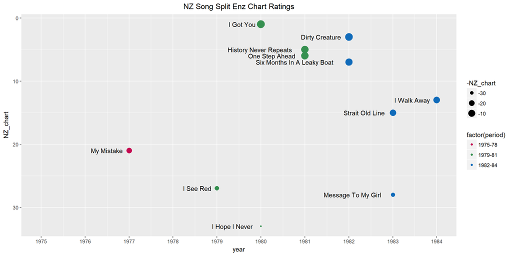

```r
Chart_ratings <- ggplot(data=Split_Enz_2) +
  geom_point(mapping = aes(x=year,y=NZ_chart,colour=factor(period),size=-NZ_chart)) + scale_y_reverse() +
  scale_colour_manual(values = my_colors) +
  geom_text(aes(x=year,y=NZ_chart,label = songs),hjust=1.2, vjust=0.5) +
  theme(plot.title = element_text(hjust = 0.5), axis.text.x = element_text(size=9, angle=0)) +
  scale_x_continuous(breaks = round(seq(min(Split_Enz_2$year), max(Split_Enz_2$year), by = 1),1)) +
# scale_y_discrete(name = "Chart Position", breaks = -Split_Enz_2$NZ_chart, labels = -Split_Enz_2$NZ_chart, limits = C(0,40)) +
  ggtitle("NZ Song Split Enz Chart Ratings")

Chart_ratings
```

## Song ratings and Album ratings back in the day

The vinyl long-playing (LP) album was in its golden era during the 1970’s and 80’s with singles sold in the 45 rpm seven-inch single in decline. The Sony Walkman was released in 1979 and the Split Enz albums (typically the same playlist to the LP) were also enjoyed on Compact Audio Cassette (CAC) format. Split Enz’s weekly album ratings highest rank in both New Zealand and Australia surpassed their song ratings, with three number 1 studio album’s:

- True Colours (1980) #1 NZ/Aus
- Waiata/Corroboree (1981) #1 NZ/Aus
- Time and Tide (1982) #1 NZ/Aus

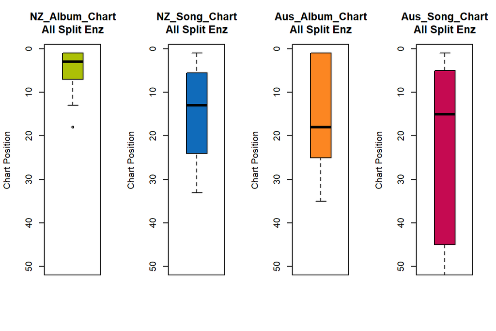

```r
par(mfrow=c(1,4))
boxplot(Split_Enz_2$NZ_album_chart,main="NZ_Album_Chart\nAll Split Enz",ylab = "Chart Position",ylim=c(50,1),col="#ACC006")
boxplot(Split_Enz_2$NZ_chart,main="NZ_Song_Chart\nAll Split Enz",ylab = "Chart Position",ylim=c(50,1),col="#106BBA")
boxplot(Split_Enz_2$AUS_album_chart,main="Aus_Album_Chart\nAll Split Enz",ylab = "Chart Position",ylim=c(50,1),col="#FC8622")
boxplot(Split_Enz_2$Aus_Chart,main="Aus_Song_Chart\nAll Split Enz",ylab = "Chart Position",ylim=c(50,1),col="#C50A51")
```

### High Album Chart Ratings

Split Enz had very high album chart ratings in New Zealand as indicated in the box plots above, it is skewed towards the top number 1 position in the chart. The album chart titled box plots https://en.wikipedia.org/wiki/Box_plot above cover all 9 Split Enz studio albums released over their 1975-1984.

Lets have a look at the most common words in Split Enz lyrics using a word cloud:

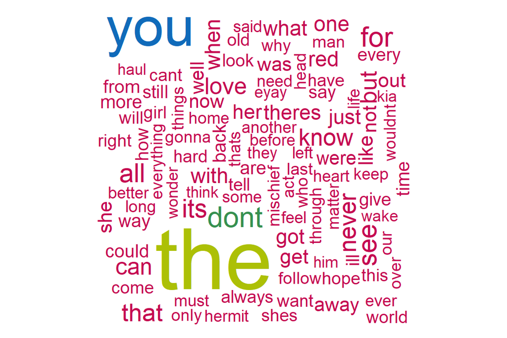

```r
words <- Corpus(VectorSource(Split_Enz_2$lyrics))

#exceptions <- grep(pattern = "not|n't", x = stopwords(), value = TRUE)
#my_stopwords <- setdiff(stopwords("english"), exceptions)

term.doc.matrix <- TermDocumentMatrix(words,
                                      control = list(removePunctuation = TRUE,
                                      #stopwords = stopwords("english"),
                                      removeNumbers = TRUE,tolower = TRUE))

tdm <- term.doc.matrix
word.matrix <- as.matrix(tdm)
#head(word.matrix)

word.freqs <- sort(rowSums(word.matrix), decreasing=TRUE)
dm <- data.frame(word=names(word.freqs), freq=word.freqs)

wordcloud(dm$word, dm$freq, colors=my_colors, rot.per=.3, scale=c(6,1),min.freq = 20,max.words = 150)
```

### Word Frequency of Songs

In music the frequency of words is important. Repetition of words and rarity of usage both affect memorability of the entire song itself.

So is there an association between Split Enz word volume in a song and their hit songs? Lets have a look:

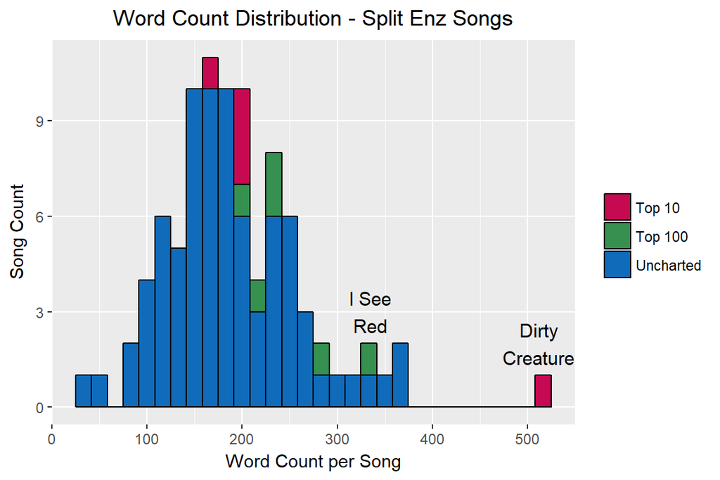

```r
# code to count the amount of words in a song:
Split_Enz_2$num_word <- sapply(gregexpr("[[:alpha:]]+", Split_Enz_2$lyrics), function(x) sum(x > 0))

###this alternative not used as slightly less accurate when tested with this data
#library(stringr)
#Split_Enz_2$num_word <- str_count(Split_Enz_2$lyrics,"\\S+")

Split_Enz_2 %>%
  ggplot() +
  geom_histogram(aes(x = num_word, fill = NZsong_chart ),color="black") +
  ggplot2::annotate("text", size= 4, x = 512, y = 2,label = "Dirty\nCreature") +
  ggplot2::annotate("text", size= 4, x = 335, y = 3,label = "I See\nRed") +
  scale_fill_manual(values = my_colors) +
  ylab("Song Count") +
  xlab("Word Count per Song") +
  ggtitle("Word Count Distribution - Split Enz Songs") +
  theme(plot.title = element_text(hjust = 0.5),
        legend.title = element_blank(),
        panel.grid.minor.y = element_blank())
```

Four of the five top 10 Split Enz hit songs are clustered between a range of 170-210 words per song. However, the hit song “Dirty Creature” springs a nasty surprise and doesn’t follow the trend of the other top 10 hits and is quite special with more than 500 words.

### High word count songs

The top 10 songs with the highest word count are:

```r
library(knitr) # for dynamic reporting
library(kableExtra) # create a nicely formated HTML table
library(formattable) # for the color_tile function

#top 10 highest word count songs
word_order <- Split_Enz_2 %>%
  select(year, NZsong_chart, songs, num_word) %>%
  arrange(desc(num_word))

word_order[1:10,] %>%
  ungroup(num_word, songs) %>%
  mutate(num_word = color_bar("lightgreen")(num_word)) %>%
  mutate(songs = color_tile("lightblue","lightblue")(songs)) %>%
  kable("html", escape = FALSE, align = "c", caption = "Split Enz Songs With Highest Word Count") %>%
  kable_styling(bootstrap_options =
                  c("striped", "condensed", "bordered"),
                full_width = FALSE)
```

Split Enz Songs With Highest Word Count

| year | NZsong_chart | songs | num_word |
| --- | --- | --- | --- |
| 1982 | Top 10 | Dirty Creature | 518 |
| 1979 | Uncharted | Hermit McDermitt | 363 |
| 1979 | Uncharted | She Got Body She Got Soul | 362 |
| 1977 | Uncharted | Without A Doubt | 343 |
| 1979 | Top 100 | I See Red | 339 |
| 1981 | Uncharted | Hard Act To Follow | 325 |
| 1976 | Uncharted | Sweet Dreams | 309 |
| 1983 | Uncharted | Our Day | 296 |
| 1983 | Top 100 | Message To My Girl | 289 |
| 1984 | Uncharted | Kia Kaha | 285 |

### Lexical Diversity

Lexical diversity is a representation of how many unique words are used in a song. This can be shown with a simple graph of the average unique words per song over the years.

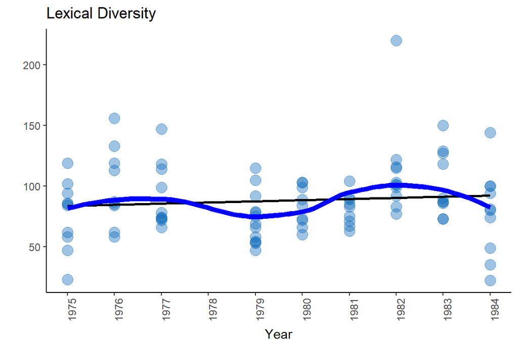

```r
lex_diversity_per_year <- Split_Enz_2 %>%
  unnest_tokens(word, lyrics) %>%
  group_by(songs,year) %>%
  summarise(lex_diversity = n_distinct(word)) %>%
  arrange(desc(lex_diversity))

diversity_plot <- lex_diversity_per_year %>%
  ggplot(aes(year, lex_diversity)) +
  scale_x_continuous(breaks = round(seq(min(Split_Enz_2$year), max(Split_Enz_2$year), by = 1),1)) +
  geom_point(color = my_colors[3],
             alpha = .4,
             size = 4,
             position = "identity") +
  stat_smooth(color = "black", se = FALSE, method = "lm") +
  geom_smooth(aes(x = year, y = lex_diversity), se = FALSE,
              color = "blue", lwd = 2) +
  ggtitle("Lexical Diversity") +
  xlab("Year") +
  ylab("") +
  scale_color_manual(values = my_colors) + theme_classic() +
  theme(axis.text.x = element_text(size=9, angle=90))

diversity_plot
```

### Lexical Density

Lexical density is the number of unique words divided by the total number of words. This is an indicator of word repetition which is an attribute of the song. As lexical density increases, repetition decreases. (Note: this does not imply sequential repetition is something different).

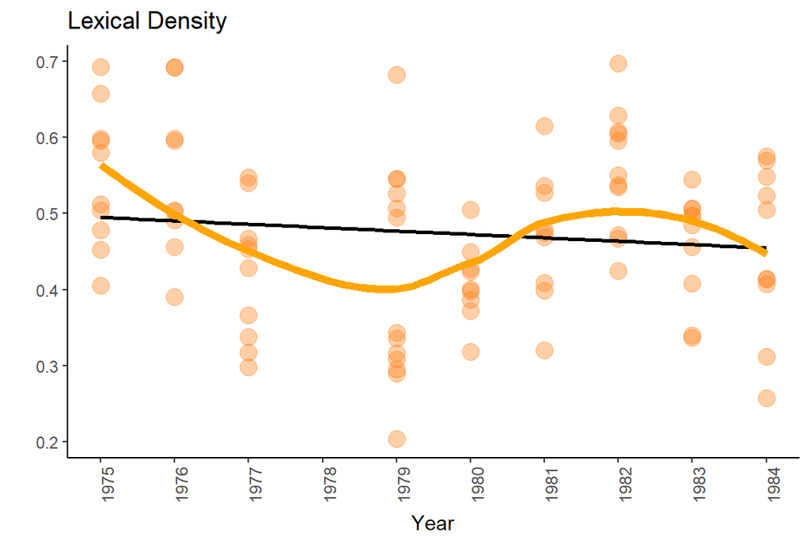

```r
#lexical density
lex_density_per_year <- Split_Enz_2 %>%
  unnest_tokens(word, lyrics) %>%
  group_by(songs,year) %>%
  summarise(lex_density = n_distinct(word)/n()) %>%
  arrange(desc(lex_density))

density_plot <- lex_density_per_year %>%
  ggplot(aes(year, lex_density)) +
  scale_x_continuous(breaks = round(seq(min(Split_Enz_2$year), max(Split_Enz_2$year), by = 1),1)) +
  geom_point(color = my_colors[4],
             alpha = .4,
             size = 4,
             position = "identity") +
  stat_smooth(color = "black",
              se = FALSE,
              method = "lm") +
  geom_smooth(aes(x = year, y = lex_density),
              se = FALSE,
              color = "orange",
              lwd = 2) +
  ggtitle("Lexical Density") +
  xlab("Year") +
  ylab("") +
  scale_color_manual(values = my_colors) + theme_classic() +
  theme(axis.text.x = element_text(size=9, angle=90))

density_plot
```

And now lets compare lexical diversity, density and weighted chart ratings all together and look for trends in the data:

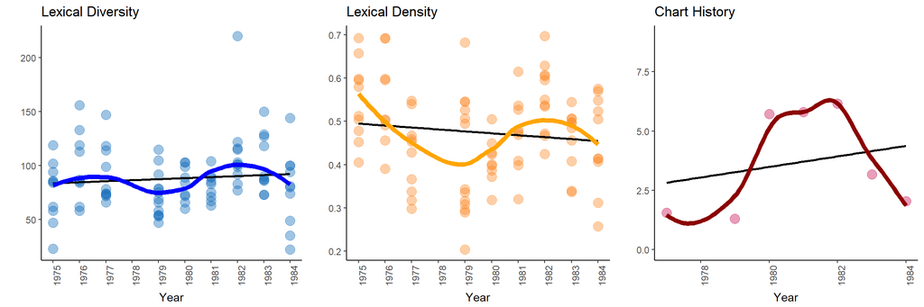

```r
#now we have the chart history

chart_history <- Split_Enz_2 %>%
  filter(NZ_chart > 0) %>%
  group_by(year, charted) %>%
  mutate(song_weight = log(100/NZ_chart)) %>%
  summarise(year_rating = sum(song_weight)) %>%
  ggplot(aes(year, year_rating)) +
  geom_point(color = my_colors[1],
             alpha = .4,
             size = 4,
             position = "identity") +
  geom_smooth(aes(x = year, y = year_rating),
              se = FALSE,
              method = "lm",
              color = "black" ) +
  geom_smooth(aes(x = year, y = year_rating),
              se = FALSE,
              color = "dark red",
              lwd = 2) +
  ggtitle("Chart History") +
  xlab("Year") +
  ylab("") +
  ylim(0,9) +
  scale_color_manual(values = my_colors) + theme_classic() +
  theme(axis.text.x = element_text(size=9, angle=90))

#chart_history

grid.arrange(diversity_plot, density_plot, chart_history, ncol = 3)
```

### Lexical Trends over time

As you can see in the chart above Split Enz’s lexical diversity increases slightly over time and was slightly higher during the 1981-1983 period. During the same period when Split Enz was producing most of its Top 100 songs 1980-1983 the average lexical density was a bit higher.

Maybe we should be content with these nice looking scatter plots and trend lines?

### Show me the money

Averages are valuable and they are commonly used statistical measure, but it is also a good idea to look more closely at the data. Let’s face it hit songs make the money and by volume stay in the memories of more fans. So let’s take a closer look..

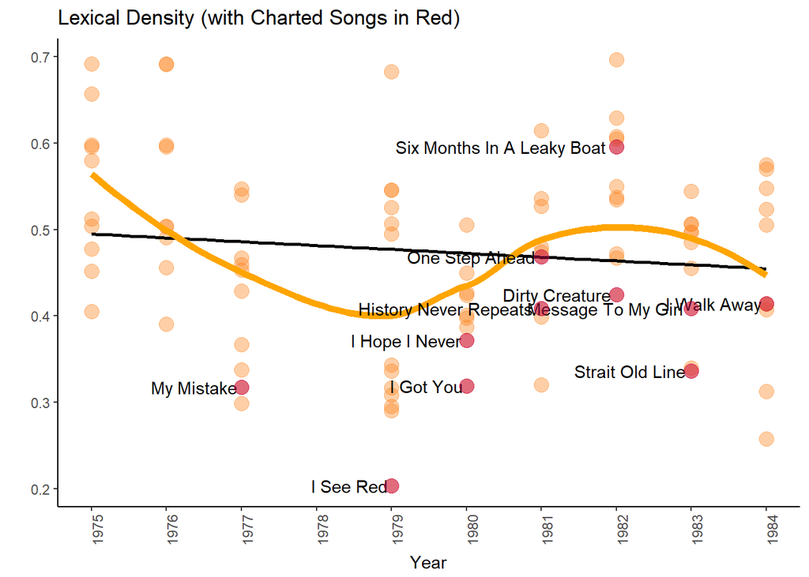

```r
label_hits <- lex_density_per_year %>%
  filter(songs %in% charted_songs_over_time$songs)

density_plot2 <- lex_density_per_year %>%
  ggplot(aes(year, lex_density)) +
  scale_x_continuous(breaks = round(seq(min(Split_Enz_2$year), max(Split_Enz_2$year), by = 1),1)) +
  geom_point(color = my_colors[4],
             alpha = .4,
             size = 4,
             position = "identity") +
  stat_smooth(color = "black",
              se = FALSE,
              method = "lm") +
  geom_smooth(aes(x = year, y = lex_density),
              se = FALSE,
              color = "orange",
              lwd = 2) +
  geom_text(data = label_hits, aes(year,lex_density, label = label_hits$songs), hjust=1.05) +
  geom_point(data=label_hits, aes(year,lex_density, label = label_hits$songs),colour="#C50A51",size = 4,alpha = .5) +
  ggtitle("Lexical Density (with Charted Songs in Red)") +
  xlab("Year") +
  ylab("") +
  scale_color_manual(values = my_colors) + theme_classic() +
  theme(axis.text.x = element_text(size=9, angle=90))

density_plot2
```

### Don’t follow that “Strait old line”

Well as shown above it looks like most of the Top 100 hits actually have a low lexical density!

### Closing remarks

Lower lexical density and more repetition appear to have some association with most of the Split Enz top charted hits (with the exception of “Six Months in a Leaky Boat” and “One Step Ahead”). In the second post I will do some Sentiment Analysis and Natural-language processing (NLP) on Split Enz lyrics. I’m looking forward to some further insight when we look deeper into Split Enz lyrics.

cheers,

Phil